# Abstract

In this project the use of auto_encoders for dimension reduction task, on astronomical objects spectrum with 4400 wavelengths is studied and the final dimension of the samples is set to 40. This feathure vectors are preprocessed to be used in regression models for predicting Z values. In the following sections, a brief overview of dataset, auto_encoders and how these models can be used for dimension reduction and finally applied regression models for predicting Z values are covered.

# Description of the dataset

The spectrum of light which is emitting from a source is measurable. Redshift happens when emitted light from the source is increased in wavelength, more precisely it represents the shift to the red end of the spectrum. Knowledge of Redshift has been used in developing technologies such as Rader gun, which is a device to determine the speed moving objects, or spectroscopic observations of astronomical objects. Redshift can be characterized by the relative difference between the observed and emitted wavelengths of an object. This is referred to as Z, which is a dimensionless quantity, in astronomical contexts.[1]  
Calculation of redshift Z, based on wavelength: $z=\frac{\lambda_{obsv}-\lambda_{emit}}{\lambda{emit}}$

As many other fields, astronomical scientists are interested in the capacity of machine learning models to predict the Z value of spectrums. However the high dimension of spectrums make the task, computationally heavy. Thus the dataset requires a preprocessing to reduce its dimensions from 4400 to 40, to make the regression model converge easier and result in a smaller error rate.

Most of the time PCA is used in dimension reduction tasks. While in this projects, Auto_encoders are applied for preprocessing data. The following section goes into details about Auto_encoders and the best result achieved in processing 5000 sample of the dataset using this technique.

# Dimension reduction using Auto_encoders

## Brief introduction into Auto_encoders:

Auto_encoder is a self supervising algorithm. The goal is to compress data. A vector of features pass to the model and gets encoded into lower dimensions by mapping function $z=f(wx+b)$. The output layer is the result of reconstruction of the encoded layer, which has the same number of features as the input vector. The described model only has one hidden layer as encoder, which its outcome vector can be used as reduced dimension, while more complex types of Auto_encoders also exists.

**Stacked Auto_encoders**:Has more than one hidden layer to encode the input feature vectors, but the decoding step happens in one step.  
**Deep Auto_encoders**:Has the same number of hidden layers to encode and decode feature vectors, in other words it is symmetric.  
In either of hidden layer combinations, the activation can be just linear or nonlinear, such as Relu for hidden layers and Sigmoid for output layer. Since the metrics for evaluating the model is Mean_Squared_error:$||X-Y||^2$, if the Sigmoid function is used as transfer function in the last layer, the input vector should be scaled to get values between 0 to 1.  
In general in this project, for the goal of better convergence, all the models run on scaled dataset.

## Code implementation:

Purpose of applied auto_encoder to astronomical spectrums, is to reduce the dimensions to 40 features, this considered as preprocessing step to the main goal of applying regression task for Z value prediction. Havin around 14000 spectrums, 5000 of it is used for traing the dimension reduction model

### Reading dataset and Libraries:

For this project different python libraries are used. The main library for implementing the Neural Network model is Keras. Keras is an open source neural network library capable of running on top of Tensorflow, Theano and MXNET. Other libraries used in this project are called in following jupyter notebook cell

```python
import h5py
import pandas as pd
import numpy as np
import tables
import matplotlib.pyplot as plt
from sklearn.preprocessing import MinMaxScaler
from sklearn.model_selection import train_test_split
from keras.layers import Input, Dense
from keras.models import Model
from keras.losses import mean_squared_error
from keras.wrappers.scikit_learn import KerasClassifier
from sklearn.model_selection import GridSearchCV
np.random.seed(seed=0)
```

Dedicating 5000 training samples for preprocessing, we have to make sure that they can be a good representation of the whole distribution of dataset. Thus, after reading the dataset, The samples are shuffled by shuffleData function.

```python
hdf = h5py.File('full15000.hdf5', 'r')
zlabels = hdf['z']
spectra = hdf['flux']
```

```python
def shuffleData(num, data,label):
    '''
    Return a total of `num` random samples and labels.
    '''
    idx = np.arange(0 , len(data))
    np.random.shuffle(idx)
    idx = idx[:num]
    data_shuffle = [data[ i] for i in idx]
    label_shuffle=[label[ i] for i in idx]
    return (np.asarray(data_shuffle),np.array(label_shuffle))
```

```python
(xx,yy)=shuffleData(14990,np.array(spectra),np.array(zlabels))
```

```python
#Getting the portion for dimention reduction training
x=xx[:5000]
y=yy[:5000]
```

### Auto_encoder architecture:

Different types of auto_encoders have been applied, and their mean_esquared_error evaluated on the testset, the following cells show the implementation of the best architecture, a stacked Auto_encoder with hidden layer dimensions 400,150 and 40.

```python
num_hidden1 = 400
num_hidden2=150#  dimensional representation of the first hidden layer
num_hidden3= 40
learning_rate = 0.01
```

For better converence, whether the output activation function is sigmoid or not, the input vectores are scaled using minmaxscale. While the first 5000 samples are used for training auto_encoder, the rest of dataset will be just passed through the encoder part of the trained model, to reduce their dimension and using it for training the regression task

```python
sc=MinMaxScaler(feature_range=(0,1))
scx=sc.fit_transform(x)
sctest=sc.transform(xx[5000:6000])
xtest=sc.transform(xx[6000:])
ytest=yy[6000:]
```

0.1 of the Auto_encoder inputs in the training set will be considered as evaluationset.

```python
#passing the scaled data to get the train test split
X_train, X_test, Y_train, Y_test = train_test_split(scx, y, train_size = 0.9)
```

```python
ncol=X_train.shape[1]
num_outputs=ncol
input_dim=Input(shape = (ncol, ))
```

The model is consist of 3 hidden layers, with linear activation function, and a fully connected layer without any activation on top of that. The middle layer will result in encodinding samples to $\color{red}{40}$

```python
encode1=Dense(num_hidden1,activation=None)(input_dim)
encode2=Dense(num_hidden2,activation=None)(encode1)
encode3=Dense(num_hidden3,activation=None)(encode2)
out=Dense(num_outputs,activation=None)(encode3)
autoencoder = Model(input = input_dim, output = out)
autoencoder.compile(optimizer = 'adam', loss = 'mean_squared_error')
autoencoder.fit(X_train, X_train, epochs = 30, batch_size = 60, shuffle = True, validation_data = (X_test, X_test),verbose=2)
```

```
Train on 4500 samples, validate on 500 samples
 - 7s - loss: 0.0023 - val_loss: 9.5610e-04
 - 6s - loss: 5.3634e-04 - val_loss: 4.7367e-04
 - 6s - loss: 3.9413e-04 - val_loss: 3.8884e-04
 - 6s - loss: 3.7095e-04 - val_loss: 3.3117e-04
 - 5s - loss: 2.8521e-04 - val_loss: 3.3051e-04
 - 5s - loss: 2.7673e-04 - val_loss: 3.4040e-04
 - 5s - loss: 3.1169e-04 - val_loss: 2.7516e-04
 - 5s - loss: 2.2947e-04 - val_loss: 2.1619e-04
 - 5s - loss: 2.0185e-04 - val_loss: 2.1639e-04
 - 5s - loss: 1.8867e-04 - val_loss: 1.9012e-04
 - 5s - loss: 1.8326e-04 - val_loss: 1.8509e-04
 - 5s - loss: 1.7091e-04 - val_loss: 1.7400e-04
 - 5s - loss: 1.7390e-04 - val_loss: 1.6523e-04
 - 5s - loss: 1.6031e-04 - val_loss: 1.6391e-04
 - 6s - loss: 1.5724e-04 - val_loss: 1.6338e-04
 - 6s - loss: 1.5147e-04 - val_loss: 1.5997e-04
 - 5s - loss: 1.7738e-04 - val_loss: 1.6366e-04
 - 6s - loss: 1.5180e-04 - val_loss: 1.5020e-04
 - 5s - loss: 1.4403e-04 - val_loss: 1.5104e-04
 - 5s - loss: 1.9685e-04 - val_loss: 3.5272e-04
 - 5s - loss: 2.5689e-04 - val_loss: 1.7619e-04
 - 5s - loss: 1.5941e-04 - val_loss: 2.0226e-04
 - 5s - loss: 1.5639e-04 - val_loss: 1.4984e-04
 - 6s - loss: 1.3140e-04 - val_loss: 1.4343e-04
 - 5s - loss: 1.2559e-04 - val_loss: 1.4253e-04
 - 6s - loss: 1.2361e-04 - val_loss: 1.6976e-04
 - 6s - loss: 1.3644e-04 - val_loss: 1.4579e-04
 - 6s - loss: 1.3280e-04 - val_loss: 1.3663e-04
 - 6s - loss: 1.3054e-04 - val_loss: 1.7604e-04
 - 6s - loss: 1.3336e-04 - val_loss: 2.1853e-04
```

```
<keras.callbacks.History at 0x162be30eba8>
```

For testing the outcome of auto_encoder, it is tested on 1000 samples.

```python
encoder = Model(inputs = input_dim, outputs = out)
#encoded_input = Input(shape = (encoding_dim, ))
encoded_out = encoder.predict(sctest)
```

The following cell computes the test error for the proposed model.

```python
testerror=mean_squared_error(sctest, encoded_out)
import tensorflow as tf
with tf.Session() as sess:
    print(sess.run(tf.reduce_mean(testerror)))
```

```
0.000188248669424
```

The following plot shows that how the reconstructed sample is matching the input sample while it avoids most of the noisy points

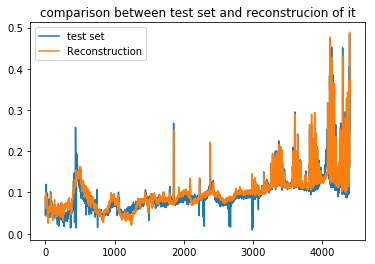

```python
%matplotlib inline
plt.plot(sctest[7],label="test set")
plt.plot(encoded_out[7],label="Reconstruction")
plt.title("comparison between test set and reconstrucion of it")
plt.legend()
```

Now the data for regression model can be passed to get encoded for final 40 dimesion.

```python
Encoding= Model(inputs =input_dim, outputs = encode3)
encoded_X = Encoding.predict(xtest)
```

# Regression model

To achieve main goal of this project, whih is predicting Z value based on wavelenghts, a regression model is appield to the new dataset with 40 features per sample. These features are not sequential any more. To address this final piece of project RandomForestRegressor from ensemble models is implemented.

## Intution into RandomForestRegressor

Ensemble models run 2 or more analtical models and synthesizing the results into a single score, in order to improve the accuracy. One the most powerful example of these models is Random ForestRegressor. It is a very powerful estimator fitting couple of decision trees on random sub_samples of the dataset and use averaging to improve the prediction accuracy. It is noticeable that, due to random sampling, these models are successful in eliminating the overfitting problem. The following cells shows the implementation of regression model using RandomForestRegression with mean_squared_error as the evaluation metrix.

```python
Xreg,X_testreg,Yreg,Y_testreg=train_test_split(encoded_X, ytest, train_size = 0.9)
```

```python
from sklearn.model_selection import cross_val_score
from sklearn.metrics import mean_squared_error
```

```python
def score_val(scores):
    print("mean %f"%(np.mean(scores)))
    print("std %f"%(np.std(scores)))
    print(scores)
```

## Choosing the best set of parameters using Gridsearch

For the purpose of tuning parameters, Gridsearchcv has been implemented based on cross_validation with 5 folds.

```python
from sklearn.ensemble import RandomForestRegressor
from sklearn.model_selection import GridSearchCV
rf2=RandomForestRegressor(n_jobs=-1)
param_grid=[{'bootstrap':[False],'n_estimators':[300,400,500,],'max_features':[8,10,15]}]
gs=GridSearchCV(rf2,param_grid,cv=5,scoring="neg_mean_squared_error")
gs.fit(Xreg,Yreg)
```

```
GridSearchCV(cv=5, error_score='raise',
       estimator=RandomForestRegressor(bootstrap=True, criterion='mse', max_depth=None,
           max_features='auto', max_leaf_nodes=None,
           min_impurity_decrease=0.0, min_impurity_split=None,
           min_samples_leaf=1, min_samples_split=2,
           min_weight_fraction_leaf=0.0, n_estimators=10, n_jobs=-1,
           oob_score=False, random_state=None, verbose=0, warm_start=False),
       fit_params=None, iid=True, n_jobs=1,
       param_grid=[{'max_features': [8, 10, 15], 'n_estimators': [300, 400, 500], 'bootstrap': [False]}],
       pre_dispatch='2*n_jobs', refit=True, return_train_score='warn',
       scoring='neg_mean_squared_error', verbose=0)
```

```python
gs.best_params_
```

```
{'bootstrap': False, 'max_features': 15, 'n_estimators': 400}
```

As the final step of the project, the regression model is applied to the dataset and evaluated on the test set. Comparison of the error rate in test set and validation set shows how the model has been successful in avoiding overfitting.

```python
rf=RandomForestRegressor(n_estimators=500,n_jobs=-1,bootstrap=False,max_features=10)
rf.fit(Xreg,Yreg)
```

```
RandomForestRegressor(bootstrap=False, criterion='mse', max_depth=None,
           max_features=10, max_leaf_nodes=None, min_impurity_decrease=0.0,
           min_impurity_split=None, min_samples_leaf=1,
           min_samples_split=2, min_weight_fraction_leaf=0.0,
           n_estimators=500, n_jobs=-1, oob_score=False, random_state=None,
           verbose=0, warm_start=False)
```

```python
scores=cross_val_score(rf,Xreg,Yreg,scoring="neg_mean_squared_error",cv=10)
cv_rmse=np.sqrt(-scores)
score_val(cv_rmse)
```

```
mean 0.084891
std 0.009487
[ 0.0956504   0.09534093  0.09519461  0.08037045  0.08006866  0.08935689
  0.08166135  0.08384738  0.08474881  0.06266972]
```

```python
testpred=rf.predict(X_testreg)
mse=mean_squared_error(Y_testreg,testpred)
rmse=np.sqrt(mse)
rmse
```

```
0.09848537222169379
```

# Conclusion

Astronomical data, in general, consist of complex and high dimension observations of different measurements and usually include noise. Machine learning and deep learning models can be a powerful tool for helping astronomers to process their dataset of interest. In this project the dimension reduction application Autoencoders, has been studied. Spectrums with 4400 wavelengths have been reduced to 40 features. This model is trained on a 1/3 of the whole dataset and applied to the rest of dataset. Thus, if the main goal of the dataset is to predict a label, whether it is classification or regression task, the model should not be very deep neural network (In order to deal with high dimension and noise of dataset) and a strong machine learning architectures like RandomForest can achieve an accordable result as well.

# Sources

$\href{https://en.wikipedia.org/wiki/Redshift#Measurement,_characterization,_and_interpretation}{[1]Redshift}$  
$\href{https://keras.io/}{[2]Keras documentation}$  
$\href{http://scikit-learn.org/stable/user_guide.html}{[3]SKlearn user guide}$